# Ejercicios de Componentes Principales

Lab: Componentes principales.

19/3/2022

# Ejercicios de práctica de componentes principales

### 1. Las tasas semanales de interés de 5 acciones listadas en el NY Stock Exchange están dadas a continuación:

```r
X <- read.delim("https://raw.githubusercontent.com/jvega68/EA3/master/datos/J%26W/T8-4.DAT",
                sep = "", header = F)
names(X) <- c("JPMorgan","Citibank","WellsFargo","Shell","Exxon")
str(X)
```

```
'data.frame':   100 obs. of  5 variables:
 $ JPMorgan  : num  0 0.027 0.1228 0.057 0.0637 ...
 $ Citibank  : num  0 -0.04485 0.06077 0.02995 -0.00379 ...
 $ WellsFargo: num  0 -0.00303 0.08815 0.06681 -0.03979 ...
 $ Shell     : num  0.0395 -0.0145 0.0862 0.0135 -0.0186 ...
 $ Exxon     : num  0 0.0435 0.0781 0.0195 -0.0242 ...
```

1. Construir la matriz de covarianza muestral **S** y encontrar las componentes principales muestrales.

```r
(S <- var(X))
```

```
               JPMorgan     Citibank   WellsFargo        Shell        Exxon
JPMorgan   0.0016299269 0.0008166676 0.0008100713 0.0004422405 0.0005139715
Citibank   0.0008166676 0.0012293759 0.0008276330 0.0003868550 0.0003109431
WellsFargo 0.0008100713 0.0008276330 0.0015560763 0.0004872816 0.0004624767
Shell      0.0004422405 0.0003868550 0.0004872816 0.0008023323 0.0004084734
Exxon      0.0005139715 0.0003109431 0.0004624767 0.0004084734 0.0007587370
```

```r
eigen(S)
```

```
eigen() decomposition
$values
[1] 0.0035953867 0.0007921798 0.0007364426 0.0005086686 0.0003437707

$vectors
           [,1]        [,2]       [,3]        [,4]        [,5]
[1,] -0.5605914  0.73884565 -0.1260222  0.28373183 -0.20846832
[2,] -0.4698673 -0.09286987 -0.4675066 -0.68793190  0.28069055
[3,] -0.5473322 -0.65401929 -0.1140581  0.50045312 -0.09603973
[4,] -0.2908932 -0.11267353  0.6099196 -0.43808002 -0.58203935
[5,] -0.2842017  0.07103332  0.6168831  0.06227778  0.72784638
```

```r
y <- as.matrix(X) %*% eigen(S)$vectors # scores
apply(y,2,var)  # reproduce los eigenvalores
```

```
[1] 0.0035953867 0.0007921798 0.0007364426 0.0005086686 0.0003437707
```

```r
# Usando las funciones definidas
z <- princomp(X)
summary(z, loadings=T)
```

```
Importance of components:
                           Comp.1     Comp.2     Comp.3     Comp.4     Comp.5
Standard deviation     0.05966098 0.02800461 0.02700145 0.02244063 0.01844812
Proportion of Variance 0.60159252 0.13255027 0.12322412 0.08511218 0.05752091
Cumulative Proportion  0.60159252 0.73414279 0.85736691 0.94247909 1.00000000

Loadings:
           Comp.1 Comp.2 Comp.3 Comp.4 Comp.5
JPMorgan    0.561  0.739  0.126  0.284  0.208
Citibank    0.470         0.468 -0.688 -0.281
WellsFargo  0.547 -0.654  0.114  0.500
Shell       0.291 -0.113 -0.610 -0.438  0.582
Exxon       0.284        -0.617        -0.728
```

2. Determinar la proporción de la varianza total explicada por las primeras tres componentes principales.

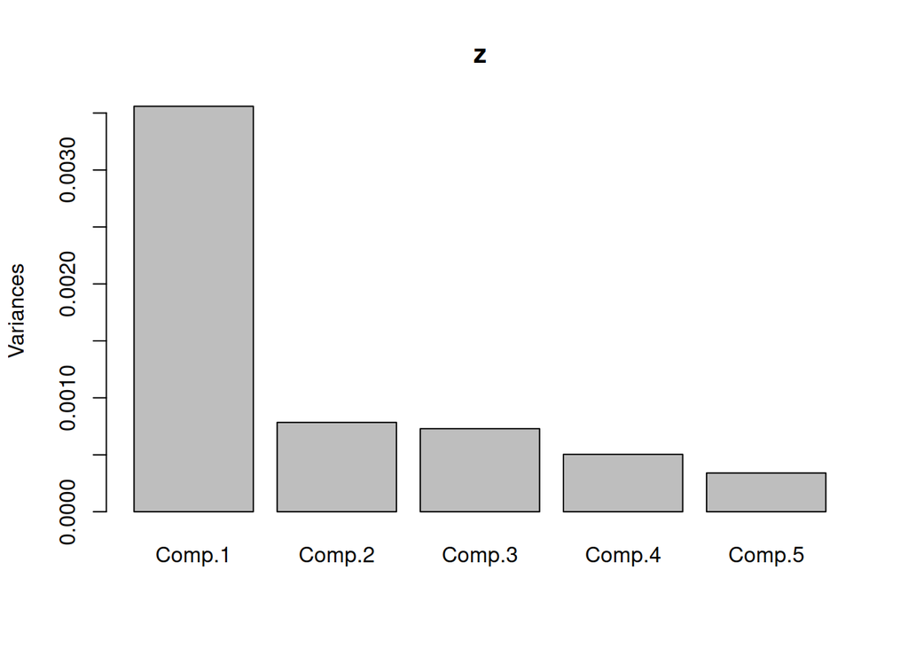

```r
screeplot(z)
```

3. Con los resultados de la pregunta anterior, ¿consideran que los datos se pueden resumir bien en menos de 5 dimensiones? Explicar.

### 2. Considerar los datos siguientes que corresponden a datos del censo de ciertas áreas geográficas (parecidas a las agebs). Las variables son:

- `V1` = Población total (en miles)
- `V2` = % de personas con grado profesional
- `V3` = % de pesonas empleadas de 16 años o más
- `V4` = % de empleados gubernamentales
- `V5` = mediana del valor de hogar, en cientos de miles de dólares.

```r
X <- read.delim("https://raw.githubusercontent.com/jvega68/EA3/master/datos/J%26W/T8-5.DAT",
                sep = "", header = F)
```

1. Construir la matriz de covarianzas muestral $S$,cuando la variable $V_5$ es registrada en diez miles de dólares.

```r
S1 <- cov(X) # con los datos originales
X$V5 <- 10*X$V5
S2 <- cov(X)
```

2. Obtener los pares de valores y vectores propios y las primeras dos componentes principales para la matriz de covarianzas del inciso (a).

```r
z <- princomp(X, cor = T)
summary(z, loadings = T)
```

```
Importance of components:
                          Comp.1    Comp.2    Comp.3    Comp.4     Comp.5
Standard deviation     1.4113534 1.1694129 0.9296006 0.7314787 0.49126036
Proportion of Variance 0.3983837 0.2735053 0.1728315 0.1070122 0.04826735
Cumulative Proportion  0.3983837 0.6718890 0.8447204 0.9517327 1.00000000

Loadings:
   Comp.1 Comp.2 Comp.3 Comp.4 Comp.5
V1  0.263  0.463  0.784  0.217  0.235
V2 -0.593  0.326 -0.164 -0.145  0.703
V3  0.326  0.605 -0.225 -0.663 -0.194
V4 -0.479 -0.252  0.551 -0.572 -0.277
V5 -0.493  0.500         0.407 -0.580
```

3. Calcular la proporción de varianza total explicada por las dos primeras componentes principales obtenidas en la parte (b). Calcular también los coeficientes de correlación $r(V_i,Y_k)$, entre las variables originales y las componentes principales.

```r
cor(scale(X),z$scores)
```

```
       Comp.1     Comp.2      Comp.3     Comp.4     Comp.5
V1  0.3705973  0.5414307  0.72871642  0.1586790  0.1153421
V2 -0.8374323  0.3808125 -0.15252194 -0.1058063  0.3452984
V3  0.4596747  0.7076608 -0.20904352 -0.4848744 -0.0954620
V4 -0.6763237 -0.2952593  0.51193186 -0.4181666 -0.1359070
V5 -0.6961095  0.5842940 -0.06397917  0.2978598 -0.2849881
```

### 3. Considerar los siguientes datos sobre contaminación. Tu trabajo es resumir estos datos en menos de $p=7$ dimensiones si es posible. Conducir un análisis de componentes principales de los datos usando tanto la matriz de varianzas y covarianzas **S** y la matriz de correlaciones **R**.

```r
X <- read.delim("https://raw.githubusercontent.com/jvega68/EA3/master/datos/J%26W/T1-5.DAT",
                sep = "", header = F)
names(X) <- c("viento", "rad_sol","CO","NO","NO2","O3", "HC")
str(X)
```

```
'data.frame':   42 obs. of  7 variables:
 $ viento : int  8 7 7 10 6 8 9 5 7 8 ...
 $ rad_sol: int  98 107 103 88 91 90 84 72 82 64 ...
 $ CO     : int  7 4 4 5 4 5 7 6 5 5 ...
 $ NO     : int  2 3 3 2 2 2 4 4 1 2 ...
 $ NO2    : int  12 9 5 8 8 12 12 21 11 13 ...
 $ O3     : int  8 5 6 15 10 12 15 14 11 9 ...
 $ HC     : int  2 3 3 4 3 4 5 4 3 4 ...
```

```r
z1 <- princomp(X)
z2 <- princomp(X, cor=T)

summary(z1)
```

```
Importance of components:
                          Comp.1     Comp.2     Comp.3      Comp.4      Comp.5
Standard deviation     17.234083 5.25384279 3.34537279 1.569785488 1.117613433
Proportion of Variance  0.872948 0.08112714 0.03289281 0.007242569 0.003671092
Cumulative Proportion   0.872948 0.95407514 0.98696795 0.994210520 0.997881611
                            Comp.6       Comp.7
Standard deviation     0.718428856 0.4523547944
Proportion of Variance 0.001516979 0.0006014096
Cumulative Proportion  0.999398590 1.0000000000
```

```r
summary(z2)
```

```
Importance of components:
                          Comp.1    Comp.2    Comp.3    Comp.4     Comp.5
Standard deviation     1.5286539 1.1772853 1.0972994 0.8526937 0.80837896
Proportion of Variance 0.3338261 0.1980001 0.1720094 0.1038695 0.09335379
Cumulative Proportion  0.3338261 0.5318262 0.7038356 0.8077051 0.90105889
                           Comp.6     Comp.7
Standard deviation     0.73259047 0.39484041
Proportion of Variance 0.07666983 0.02227128
Cumulative Proportion  0.97772872 1.00000000
```

```r
z1$loadings
```

```
Loadings:
        Comp.1 Comp.2 Comp.3 Comp.4 Comp.5 Comp.6 Comp.7
viento                        0.920  0.342         0.170
rad_sol -0.993  0.116
CO                    -0.183 -0.138  0.650 -0.564 -0.444
NO                    -0.130 -0.328  0.643  0.498  0.463
NO2            -0.150 -0.955  0.102 -0.207         0.105
O3      -0.112 -0.973  0.170
HC                            0.110         0.657 -0.738

               Comp.1 Comp.2 Comp.3 Comp.4 Comp.5 Comp.6 Comp.7
SS loadings     1.000  1.000  1.000  1.000  1.000  1.000  1.000
Proportion Var  0.143  0.143  0.143  0.143  0.143  0.143  0.143
Cumulative Var  0.143  0.286  0.429  0.571  0.714  0.857  1.000
```

```r
z2$loadings
```

```
Loadings:
        Comp.1 Comp.2 Comp.3 Comp.4 Comp.5 Comp.6 Comp.7
viento   0.237  0.278  0.643  0.173  0.561  0.224  0.241
rad_sol -0.206 -0.527  0.224  0.778 -0.156
CO      -0.551        -0.114         0.573  0.110 -0.585
NO      -0.378  0.435 -0.407  0.291         0.450  0.461
NO2     -0.498  0.200  0.197               -0.745  0.338
O3      -0.325 -0.567  0.160 -0.508         0.331  0.417
HC      -0.319  0.308  0.541 -0.143 -0.566  0.266 -0.314

               Comp.1 Comp.2 Comp.3 Comp.4 Comp.5 Comp.6 Comp.7
SS loadings     1.000  1.000  1.000  1.000  1.000  1.000  1.000
Proportion Var  0.143  0.143  0.143  0.143  0.143  0.143  0.143
Cumulative Var  0.143  0.286  0.429  0.571  0.714  0.857  1.000
```

- ¿Qué se puede aprender de este ejercicio?
- ¿Hay alguna diferencia en qué matriz se escoja para el análisis?
- ¿Pueden los datos resumirse en menos de tres o menos dimensiones?
- ¿Se podrían interpretar las componentes principales?

### 4. Los datos de los records del track atlético internacional se encuentran en los datos a continuación:

```r
X <- read.delim("https://raw.githubusercontent.com/jvega68/EA3/master/datos/J%26W/T1-9.DAT",
                sep = "", header = F)
names(X) <- c("s100m","s200m","s400m","m800m","m1500m","m3000m","mMaraton","pais")
str(X)
```

```
'data.frame':   55 obs. of  8 variables:
 $ s100m   : num  11.6 11.2 11.4 11.4 11.5 ...
 $ s200m   : num  22.9 22.4 23.1 23 23.1 ...
 $ s400m   : num  54.5 51.1 50.6 52 53.3 ...
 $ m800m   : num  2.15 1.98 1.99 2 2.16 2.1 2.18 2 2.05 2.08 ...
 $ m1500m  : num  4.43 4.13 4.22 4.14 4.58 4.49 4.45 4.06 4.23 4.33 ...
 $ m3000m  : num  9.79 9.08 9.34 8.88 9.81 9.77 9.51 8.81 9.37 9.31 ...
 $ mMaraton: num  179 152 159 158 170 ...
 $ pais    : chr  "argentin" "australi" "austria" "belgium" ...
```

```r
rownames(X) <-X$pais
X$pais <- NULL
```

1. Obtener la matriz de correlación R para estos datos y determinar sus valores y vectores propios

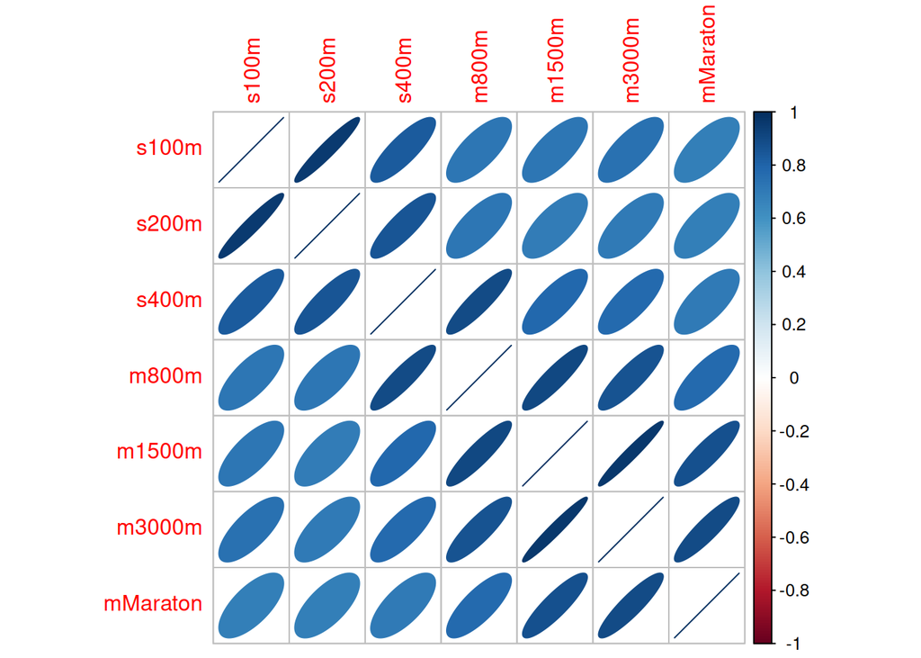

```r
library(corrplot)
corrplot(cor(X), method = "ellipse")
```

2. Determinar las primeras dos componentes principales para las variables estandarizadas. Preparar una tabla mostrando las correlaciones de las variables estandarizadas con las componentes y el porcentaje acumulado de la varianza total (estandarizada) explicada por las dos componentes.

```r
z <- prcomp(X, scale = T)
scores <- predict(z,X)
```

3. Interpretar las dos primeras componente obtenidas en (b).
4. Ordenar a las naciones basados en su score en la primera componente principal. ¿Este orden corresponde a su noción intuitiva de excelencia atlética para los diferentes países?
5. Convertir los registros a velocidades medidas en metros por segundo. Noten que los registros para 800m, 1500m, 3000m y los datos de maratón están en minutos. El maraton es 26.2 millas o 42,195 metros. Realizar un análisis de componentes principales usando la matriz de covarianzas **S** de los datos de velocidad. Comparar los resultados con los dados en los primeros incisos del ejercicio. ¿Difiere la interpretación de los resultados? Si las naciones son ordenadas sobre la base de su score en la primera componente principal, los ordenamientos subsecuentes difieren de los previos? ¿Qué análisis prefieren y porqué?

### Ejercicio de estimación de la distribución muestral de los valores propios

Podemos usar la técnica de bootstrap para encontrar intervalos de confianza para los valores propios estimados

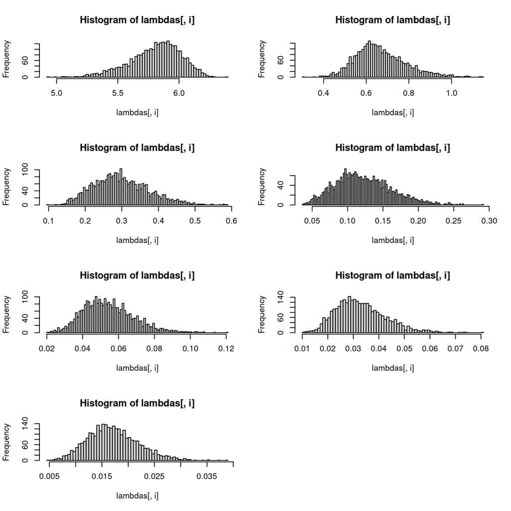

```r
pca <- function(x){eigen(cor(x))$values}
B <- 3000  # número de simulaciones bootstrap
n <- nrow(X) # número de observaciones en la muestra

lambdas <- matrix(0,nrow = B,ncol = 7)
for (i in 1:B){
  ind <- sample(1:n, replace = T)
  lambdas[i,] <- pca(X[ind,])
}
par(mfrow=c(4,2))
for(i in 1:7)hist(lambdas[,i], breaks = 100)
```